# 二手車預測模型

林德昌

2017年5月18日

```r
library(dplyr)
library(readr)
library(e1071)
library(miscTools)
library(randomForest)
trainset = read_csv("trainset-2.csv")
colnames(trainset)
```

```
##  [1] "id"                  "dateCrawled"         "name"
##  [4] "seller"              "offerType"           "price"
##  [7] "abtest"              "vehicleType"         "yearOfRegistration"
## [10] "gearbox"             "powerPS"             "model"
## [13] "kilometer"           "monthOfRegistration" "fuelType"
## [16] "brand"               "notRepairedDamage"   "dateCreated"
## [19] "nrOfPictures"        "postalCode"          "lastSeen"
## [22] "ad_exist_time"
```

```r
usedcol = c("vehicleType","gearbox","fuelType","brand","notRepairedDamage")
trainset[usedcol] = lapply(trainset[usedcol],function(x){as.factor(x)})
```

## 變數選取

在挑選變數之前，我們先畫出各變數和價格的關係圖，從圖形上能夠看出各變數和價格是否有一些相關性。

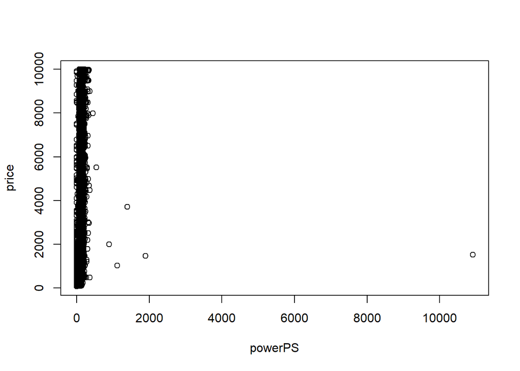

```r
with(trainset,plot(powerPS,price,type = "p"))
```

從圖表上來看，powerPS(馬力)顯然受到離群值的影響，故無法從圖形當中得知馬力和價格的關係。

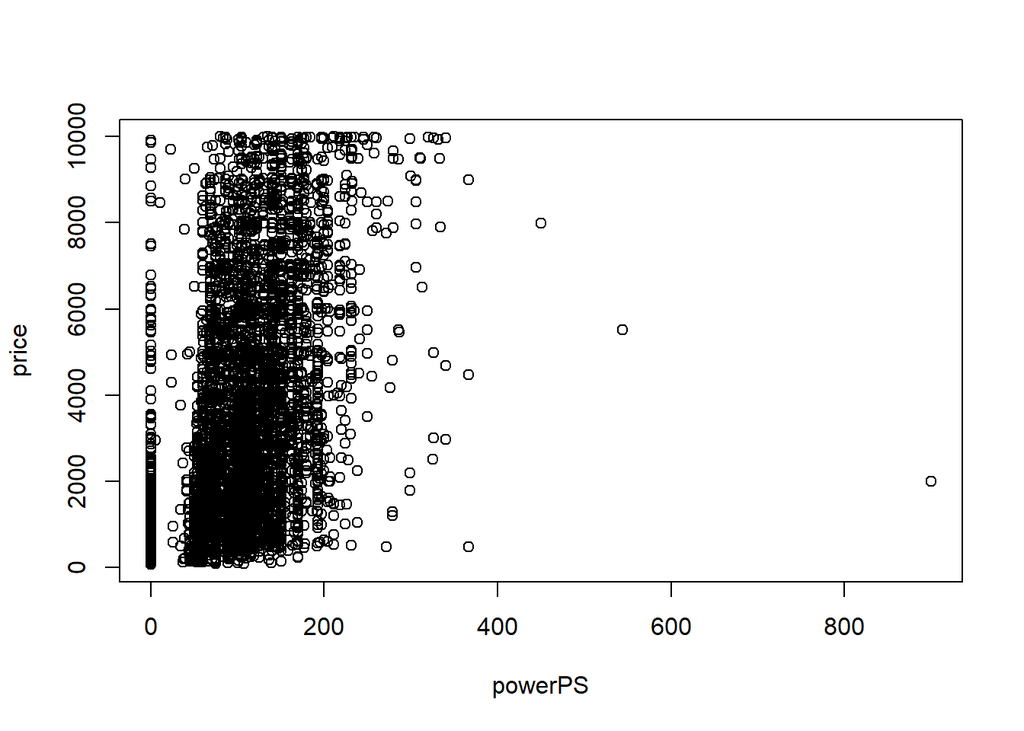

```r
trainset1 =trainset[trainset$powerPS<=1000,]  #powerPS is not a good explanatory.
with(trainset1,plot(powerPS,price,type = "p"))
```

由於powerPS(馬力)存在離群值，我們將馬力小於等於1000的資料篩選出，再畫一次圖，發現馬力和價格之間並沒有相關性。

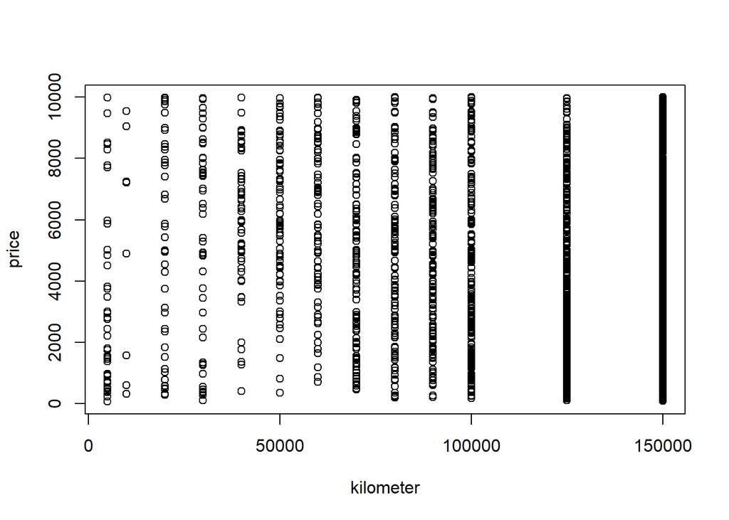

```r
with(trainset,plot(kilometer,price,type = "p"))  #kilometer is not a good explanatory.
```

由圖中可以看出，kilometer(里程數)和價格並沒有明確的相關性。

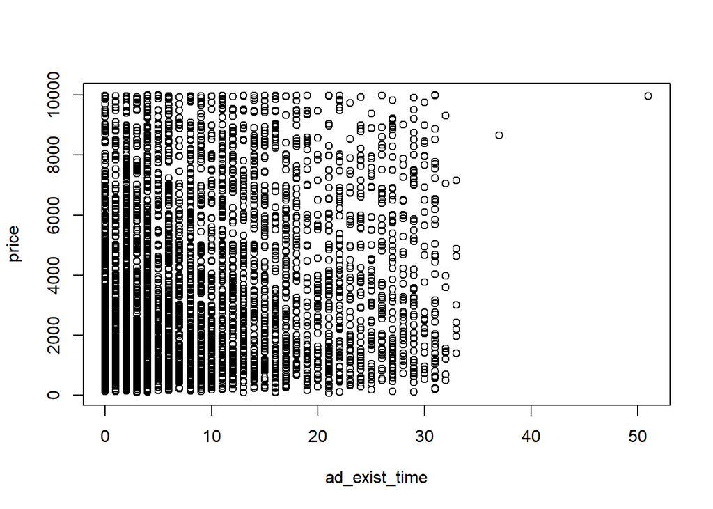

```r
with(trainset,plot(ad_exist_time,price))
```

由圖中可以看出，ad_exist_time(商品在網站上留存的時間)和價格高低並沒有明確的相關性，因而亦不考慮這項變數。

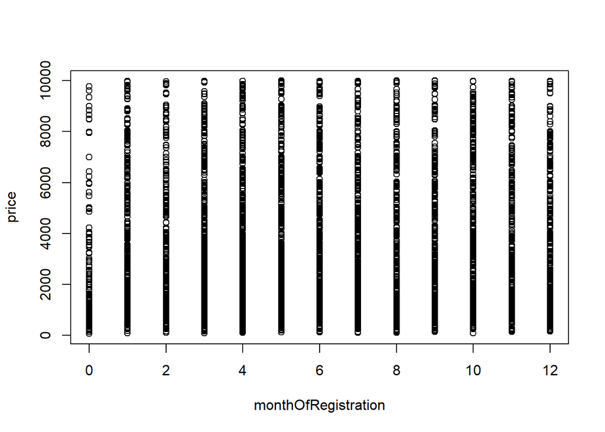

```r
with(trainset,plot(monthOfRegistration,price))
```

由圖中可以看出，monthOfRegistration(汽車註冊的月份)和價格高低亦無明確的相關性。

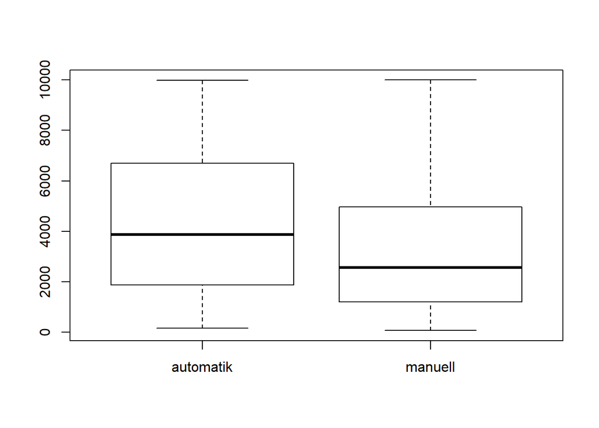

```r
#以下為可用變數
with(trainset,plot(gearbox,price,type = "h"))
```

由圖中可以看出，automatik(自排)和manuell(手排)之間的平均價格是有差異的，因此可列入變數之中來跑看看。

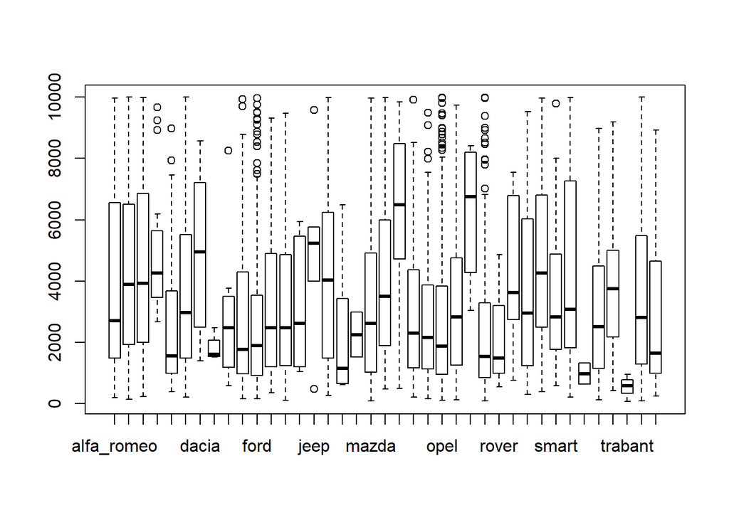

```r
with(trainset,plot(brand,price))
```

從圖中可以看出，各個brand(品牌)之間二手車的平均價格是有差異的，因此可列入變數之中來跑看看。

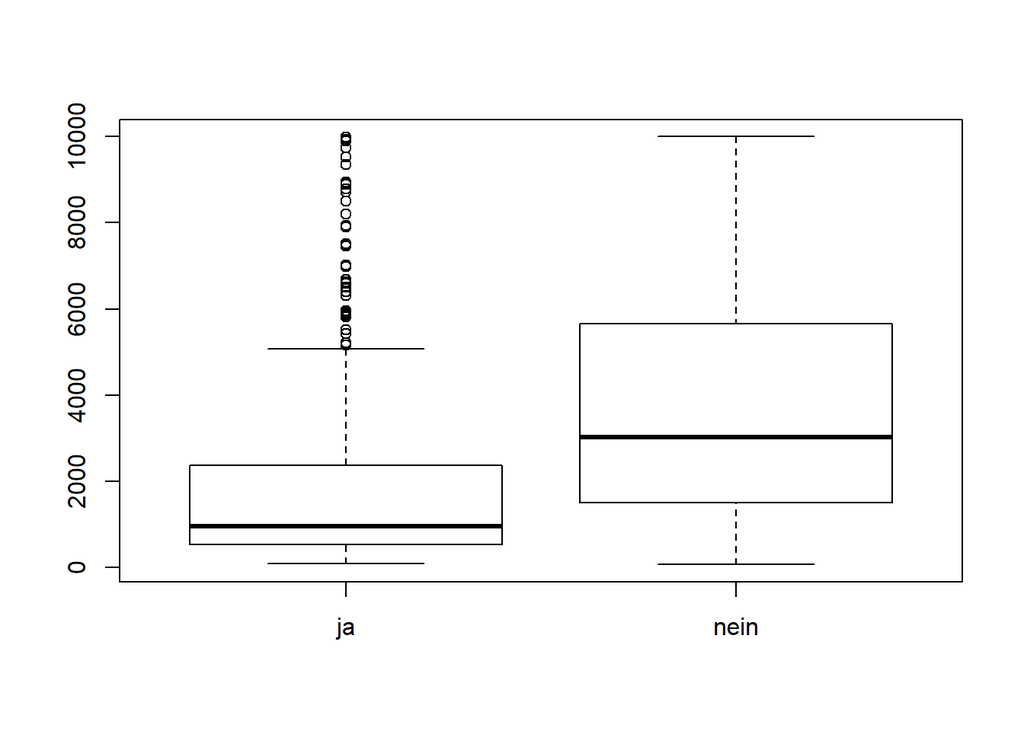

```r
with(trainset,plot(notRepairedDamage,price))
```

notRepairedDamage代表汽車是否有損害但尚未修好的地方，從圖形上來看，ja(是)的二手車平均價格明顯低於nein(沒有)的價格，因而此變數可列入模型考慮。

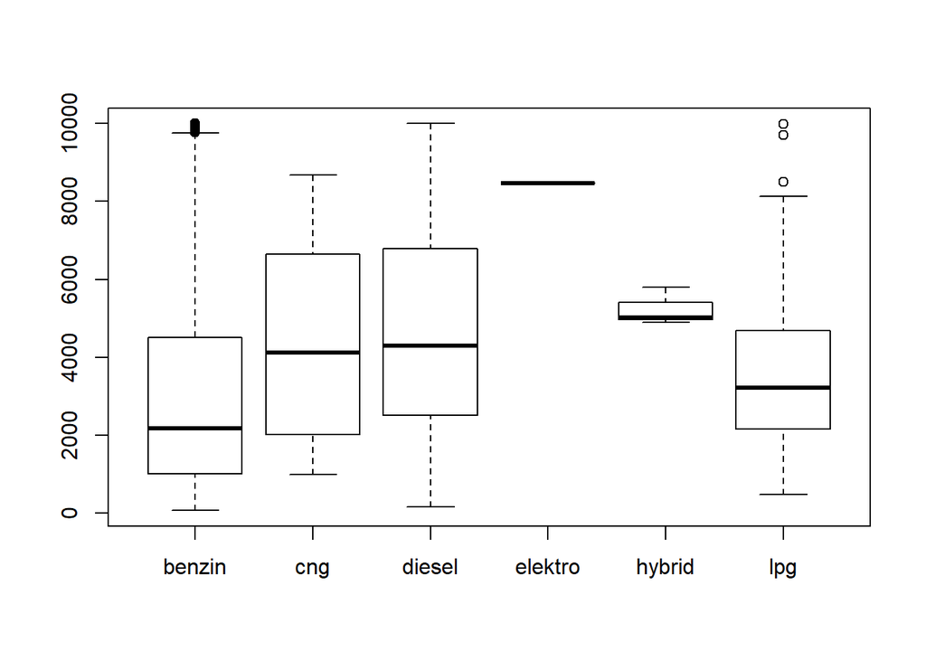

```r
with(trainset,plot(fuelType,price))
```

從圖中可以看出，各fuelType(燃料種類)之間二手車的平均價格是有差異的，因此可列入變數之中來跑看看。

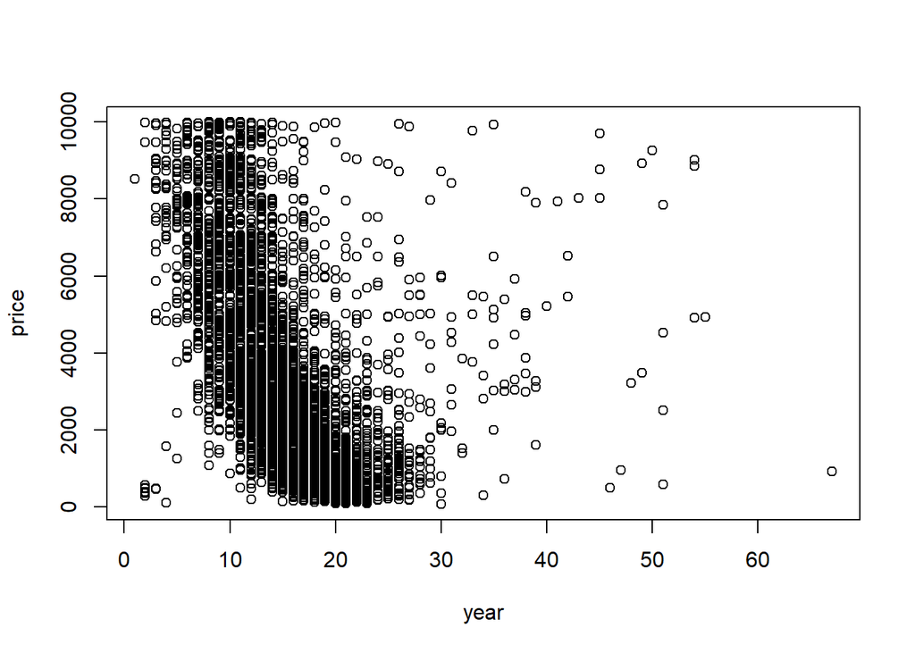

```r
year = 2017 - trainset$yearOfRegistration
with(trainset,plot(year,price))
```

```r
cor(year,trainset$price)
```

```
## [1] -0.5130789
```

我們以今年2017減去二手車的註冊年度(yearOfRegistration)作為其車齡(year)，從圖中可以看出價格和車齡之間有負向關係，相關係數也為-0.513。因此車齡(year)是可以列入模型的變數。

## 看各類別資料量的比較

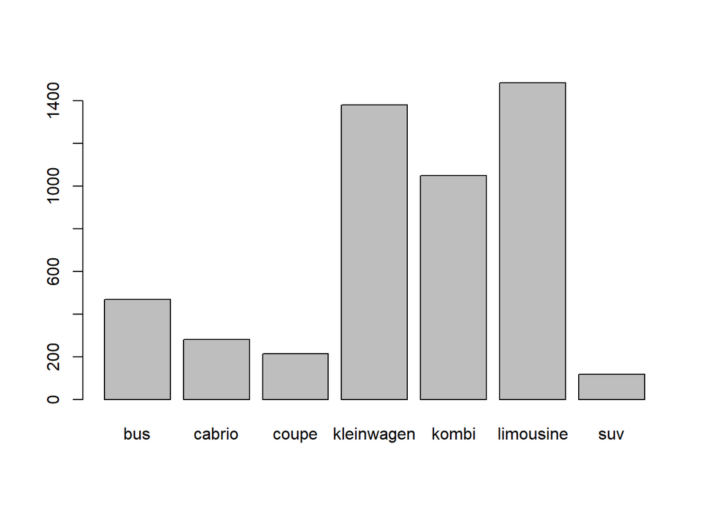

```r
barplot(table(trainset$vehicleType))
```

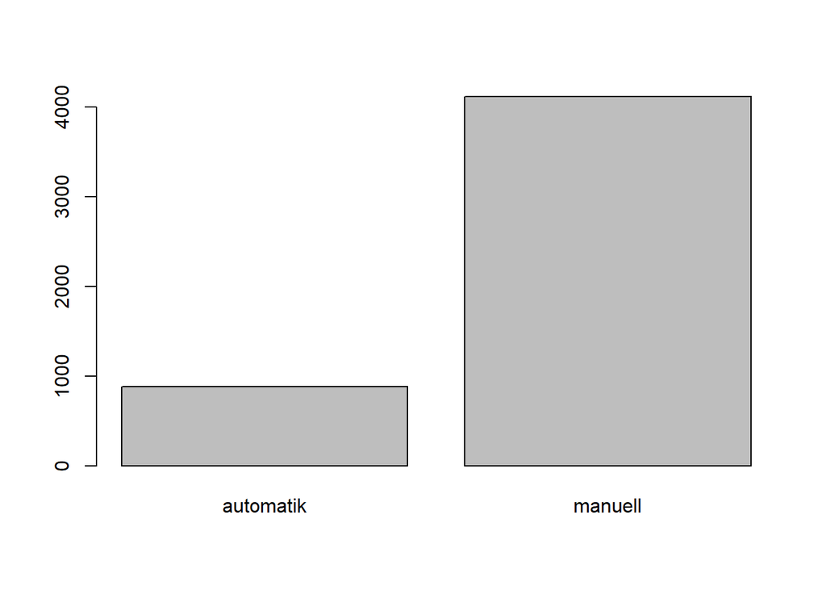

```r
barplot(table(trainset$gearbox))
```

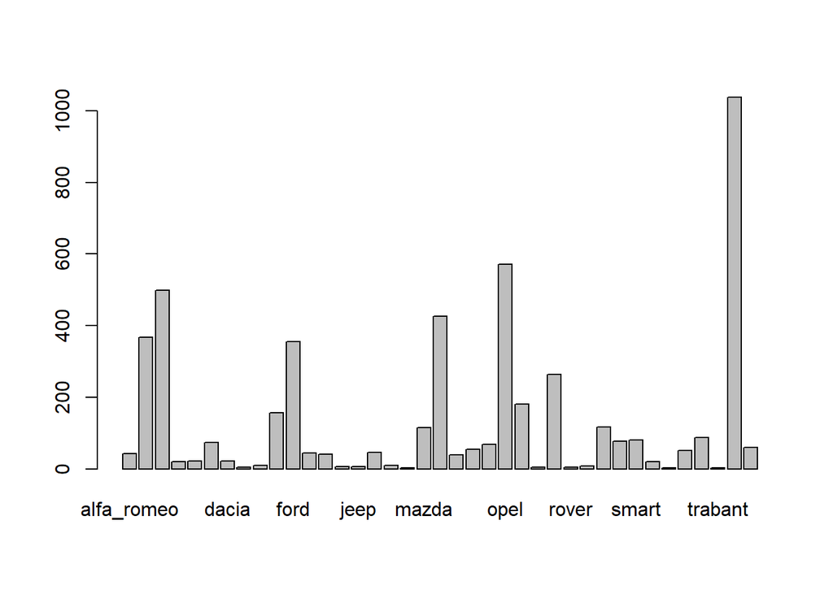

```r
barplot(table(trainset$brand))
```

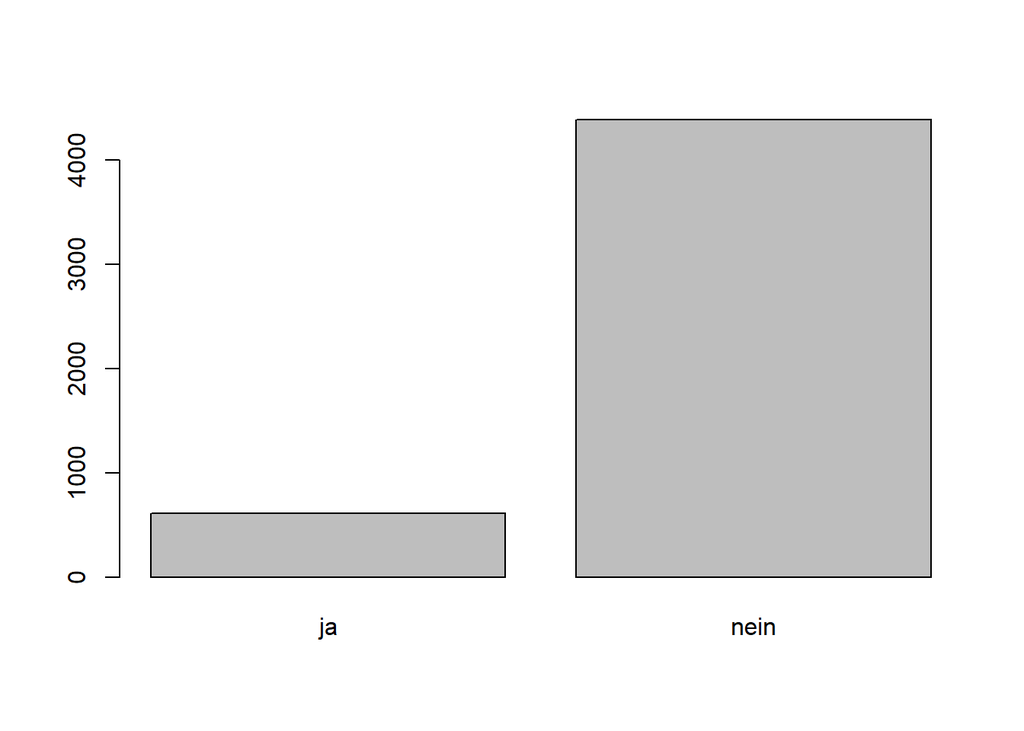

```r
barplot(table(trainset$notRepairedDamage))
```

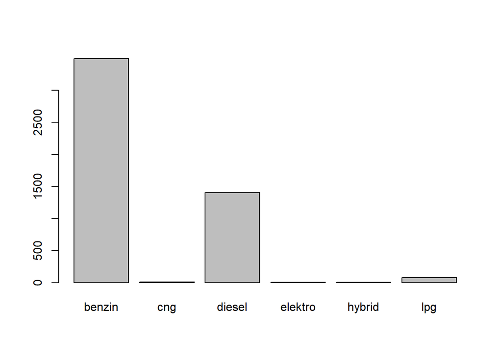

```r
barplot(table(trainset$fuelType))
```

```r
sort(table(trainset$brand),T)
```

```
##
##     volkswagen           opel            bmw  mercedes_benz           audi
##           1038            572            498            426            368
##           ford        renault        peugeot           fiat           seat
##            356            264            181            156            117
##          mazda         toyota          smart          skoda        citroen
##            115             87             81             78             74
##         nissan          volvo     mitsubishi         suzuki            kia
##             69             60             55             51             46
##          honda     alfa_romeo        hyundai           mini       chrysler
##             45             43             41             40             21
##          dacia      chevrolet sonstige_autos       daihatsu         lancia
##             21             20             20              9              9
##           saab         jaguar           jeep         daewoo        porsche
##              8              6              6              4              4
##          rover        trabant     land_rover         subaru
##              4              3              2              2
```

```r
sort(table(trainset$gearbox),T)
```

```
##
##   manuell automatik
##      4118       882
```

```r
sort(table(trainset$vehicleType),T)
```

```
##
##  limousine kleinwagen      kombi        bus     cabrio      coupe
##       1485       1382       1050        470        282        213
##        suv
##        118
```

```r
sort(table(trainset$notRepairedDamage),T)
```

```
##
## nein   ja
## 4391  609
```

```r
sort(table(trainset$fuelType),T)
```

```
##
##  benzin  diesel     lpg     cng  hybrid elektro
##    3496    1409      82       9       3       1
```

## 將資料分為trainset和testset

從各類別資料量的比較圖當中，可看出有些變數存在著資料筆數較少的類別，少到連隨機抽樣的方式有可能抽不到。因此我們讓那些少數類別直接“內定”為trainset，以確保訓練模型時能夠訓練到類別較少的部分。

```r
#將較少資料量的類別"內定"為trainset的一部分，以求訓練過程得以顧及到少數類別
sebrand = names(table(trainset$brand))[table(trainset$brand)<200]
senot = "ja"
sefuel = names(table(trainset$fuelType))[table(trainset$fuelType)<120]
segearbox = "automatik"
sevetype = names(table(trainset$vehicleType))[table(trainset$vehicleType)<500]

dta = data.frame(price = as.numeric(trainset$price),
                 gearbox = as.factor(trainset$gearbox),
                 brand = as.factor(trainset$brand),
                 notRepairedDamage = as.factor(trainset$notRepairedDamage),
                 fuelType = as.factor(trainset$fuelType),
                 vehicleType = as.factor(trainset$vehicleType),
                 year = (2017-trainset$yearOfRegistration))

dta1 = dta[dta$brand %in% sebrand|dta$fuelType %in% sefuel,]
dta2 = dta[-as.numeric(row.names(dta1)),]

set.seed(123)
num = sample(nrow(dta2),3500-1538)
dta3 = dta2[num,]
dta4 = dta2[-num,]

train = rbind(dta1,dta3)
test = dta4
```

## 用SVR預測

```r
#SVR
model1 = svm(price~.,data = train,gamma=0.125,cost=1,epsilon=0.1,kernel="radial",
             type="eps")
pred = predict(model1,test)
r2 = rSquared(test$price,test$price-pred)
print(model1)
```

```
##
## Call:
## svm(formula = price ~ ., data = train, gamma = 0.125, cost = 1,
##     epsilon = 0.1, kernel = "radial", type = "eps")
##
##
## Parameters:
##    SVM-Type:  eps-regression
##  SVM-Kernel:  radial
##        cost:  1
##       gamma:  0.125
##     epsilon:  0.1
##
##
## Number of Support Vectors:  2673
```

```r
r2
```

```
##           [,1]
## [1,] 0.7161271
```

R-squared值為0.716

## 用Random Forest預測

```r
#random forest
rf = randomForest(price~.,data = train)
pred2 = predict(rf,test)
r2 = rSquared(test$price,test$price-predict(rf,test))
print(rf)
```

```
##
## Call:
##  randomForest(formula = price ~ ., data = train)
##                Type of random forest: regression
##                      Number of trees: 500
## No. of variables tried at each split: 2
##
##           Mean of squared residuals: 2057167
##                     % Var explained: 70.12
```

```r
r2
```

```
##           [,1]
## [1,] 0.7152321
```

R-squared值為0.715